# Advanced Biostatistics Cours 2

21 octobre 2020

## Outline

- A. Tests statistiques
- Test \(t\) de Welch / Student
- Test du \(\chi2\).
- Test exact de Fisher
- B. Mesures de l’effet traitement

## Tests statistiques

## Continuous Variables

## Example

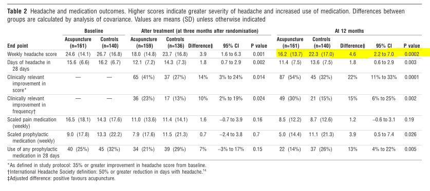

## Welch \(t\)-test

\[ t=\frac{\bar{x}_1 - \bar{x}_0}{\sqrt{\frac{s_0^2}{n_0}+\frac{s_1^2}{n_1}}} \]

\[ se(\bar{x}_1 - \bar{x}_0) = \sqrt{{s_0^2}/{n_0}+{s_1^2}/{n_1}} \]

- 95% Confidence Interval

\[ IC = \bar{x}_1 - \bar{x}_0 \pm t_{\nu, \alpha/2} * se(\bar{x}_1 - \bar{x}_0)\] with \(\nu\) = No. of degrees of freedom.

## Welch \(t\)-test in R

```r
t.test(pk5 ~ group, data = compl, alternative="two.sided",
                var.equal=FALSE)
```

```
##
##  Welch Two Sample t-test
##
## data:  pk5 by group
## t = 3.3892, df = 266.6, p-value = 0.0008069
## alternative hypothesis: true difference in means is not equal to 0
## 95 percent confidence interval:
##  2.554924 9.638399
## sample estimates:
## mean in group 0 mean in group 1
##        22.34345        16.24679
```

## Student's \(t\)-test (assumes equal variances)

```r
t.test(pk5 ~ group, data = compl, alternative="two.sided",
                var.equal=TRUE)
```

```
##
##  Two Sample t-test
##
## data:  pk5 by group
## t = 3.4399, df = 299, p-value = 0.0006648
## alternative hypothesis: true difference in means is not equal to 0
## 95 percent confidence interval:
##  2.608793 9.584530
## sample estimates:
## mean in group 0 mean in group 1
##        22.34345        16.24679
```

## \(z\)-test (for info only)

```r
library("BSDA")
z.test(compl$pk5[compl$group == 0], compl$pk5[compl$group == 1],
       sigma.x = sd(compl$pk5[compl$group == 0]),
       sigma.y = sd(compl$pk5[compl$group == 1]))
```

## Wilcoxon test

- Non parametric test
- Compare the distribution
- Use the rank of observations

```r
wilcox.test(pk5 ~ group, data = compl, correct = F)
```

```
##
##  Wilcoxon rank sum test
##
## data:  pk5 by group
## W = 14148, p-value = 0.0001327
## alternative hypothesis: true location shift is not equal to 0
```

## Categorical variables

## Example

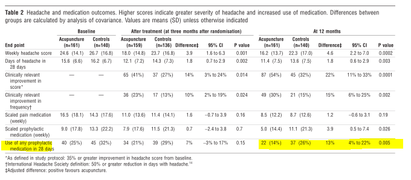

## Variable Creation

```r
compl$anypro5 <- as.numeric(compl$sprophm5>0)
table(compl$anypro5)
```

```
##
##   0   1
## 242  59
```

## Pearson's chi-square test

The value of the test-statistic is

\[ \chi^2 = \sum_{i,j} \frac{(O_{ij} - E_{ij})^2}{E_{ij}} \]

where :

- \(O_{ij}\) = the number of observations in each cell \(i,j\)
- \(E_{ij}\) = the expected (theoretical) count of type under the null hypothesis

## Chi-square test in R

```r
chi <- chisq.test(table(compl$anypro5, compl$group), correct = F)
chi$expected
```

```
##
##             0         1
##   0 112.55814 129.44186
##   1  27.44186  31.55814
```

```r
chi
```

```
##
##  Pearson's Chi-squared test
##
## data:  table(compl$anypro5, compl$group)
## X-squared = 7.7415, df = 1, p-value = 0.005397
```

## Chi-square test with Yate's continuity correction

```r
chisq.test(compl$anypro5, compl$group, correct = TRUE)
```

```
##
##  Pearson's Chi-squared test with Yates' continuity correction
##
## data:  compl$anypro5 and compl$group
## X-squared = 6.9527, df = 1, p-value = 0.008369
```

## \(z\)-test for a proportion

```r
prop.test(table(compl$anypro5, compl$group), correct = FALSE)
```

```
##
##  2-sample test for equality of proportions without continuity
##  correction
##
## data:  table(compl$anypro5, compl$group)
## X-squared = 7.7415, df = 1, p-value = 0.005397
## alternative hypothesis: two.sided
## 95 percent confidence interval:
##  -0.33972284 -0.06327478
## sample estimates:
##    prop 1    prop 2
## 0.4256198 0.6271186
```

## Fisher's exact test

```r
fisher.test(compl$anypro5, compl$group)
```

```
##
##  Fisher's Exact Test for Count Data
##
## data:  compl$anypro5 and compl$group
## p-value = 0.005844
## alternative hypothesis: true odds ratio is not equal to 1
## 95 percent confidence interval:
##  0.2331409 0.8213245
## sample estimates:
## odds ratio
##  0.4418145
```

## Treatment effect measures

## Different treatment effect measures

1. Mean Difference: MD  
   Différence des moyennes, critère de jugement quantitatif continue
2. Risk Difference: RD  
   Différence de risque, critère de jugement catégoriel (binaire)
3. Odds Ratio: OR  
   Rapport de cotes, critère de jugement catégoriel (binaire)
4. Relative Risk: RR  
   Risque relatif, critère de jugement catégoriel (binaire)

Toujours rapporter l'IC à 95% avec l'estimation ponctuelle !

## Mean Difference

- Exemple *Weekly Headache Score* at 12 months

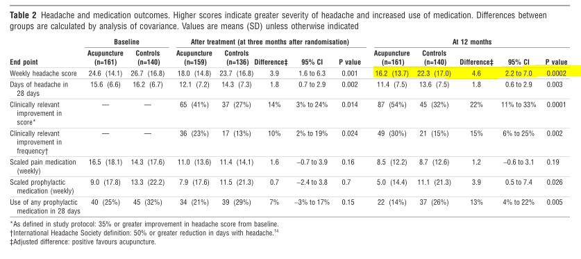

## Compute MD with R

\[MD = \bar{x}_1 - \bar{x}_0 \]

- Dans R ?

## Compute MD with R

```r
by(compl$pk5, compl$group, mean)
```

```
## compl$group: 0
## [1] 22.34345
## ------------------------------------------------------------
## compl$group: 1
## [1] 16.24679
```

```r
by(compl$pk5, compl$group, sd)
```

```
## compl$group: 0
## [1] 17.01089
## ------------------------------------------------------------
## compl$group: 1
## [1] 13.71828
```

## Compute MD with R

```r
diff(by(compl$pk5, compl$group, mean))
```

```
## [1] -6.096661
```

## Confidence interval of the Mean Difference

- First assume the *true* variance is the same in both groups
- Pooled standard deviation : \[s=\displaystyle \sqrt{\frac{(n_0-1)s_0^2 + (n_1-1) s_1^2}{n_0+n_1-2}}\]
- Standard error \[se(\bar{x}_1 - \bar{x}_0) = s \times \sqrt{\frac{1}{n_0}+\frac{1}{n_1}}\]

## Confidence interval of the Mean Difference

The confidence interval is: \[\bar{x}_1 - \bar{x}_0 \pm t_{\alpha/2;n_0+n_1-2} se(\bar{x}_1 - \bar{x}_0)\]

## Confidence interval of the Mean Difference in R base

```r
x1bar <- 16.24679
x0bar <- 22.34345
se0 <- 17.01
se1 <- 13.71
n0 <- 140
n1 <- 161

d <- x1bar - x0bar
d
```

```
## [1] -6.09666
```

## CI of MD R base

```r
spooled <- sqrt( ((n0-1)*se0**2 + (n1-1)*se1**2) / (n0 + n1 - 2))
sem <- spooled * sqrt(1/n0 + 1/n1)
d + qt(p = c(0.025, 0.5, 0.975), df = n0+n1-2) * sem
```

```
## [1] -9.583523 -6.096660 -2.609797
```

## CI of MD with t.test

```r
t.test(pk5 ~ group, data = compl, alternative="two.sided",
                var.equal=T)
```

```
##
##  Two Sample t-test
##
## data:  pk5 by group
## t = 3.4399, df = 299, p-value = 0.0006648
## alternative hypothesis: true difference in means is not equal to 0
## 95 percent confidence interval:
##  2.608793 9.584530
## sample estimates:
## mean in group 0 mean in group 1
##        22.34345        16.24679
```

## CI of MD with package Epi

```r
library(Epi)
effx(pk5, exposure = group, data = dat)
```

```
## ---------------------------------------------------------------------------
## response      :  pk5
## type          :  metric
## exposure      :  group
##
## group is numeric
## effects are measured as differences in means
## ---------------------------------------------------------------------------
##
## effect of an increase of 1 unit in group on pk5
## number of observations  301
##
## Effect   2.5%  97.5%
##  -6.10  -9.57  -2.62
##
## Test for no effects of exposure on 1 df: p-value= 0.000582
```

## Categorical variables

## Risk Difference: RD

- Binary Criteria
- Example: *Use of any prophylactic medication in 28 days*

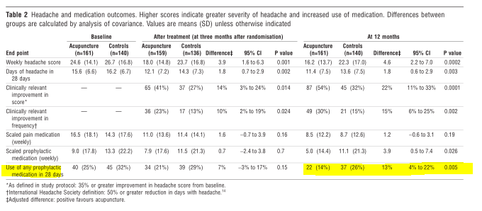

- \(\Delta\) Differences are adjusted in the article, see next classes

## Compute it with R

- Compute it with R

## 2 x 2 table

```r
CrossTable(compl$anypro5, compl$group, prop.r = F,
           prop.t = F, prop.chisq = F)
```

```
##
##
##    Cell Contents
## |-------------------------|
## |                       N |
## |           N / Col Total |
## |-------------------------|
##
##
## Total Observations in Table:  301
##
##
##               | compl$group
## compl$anypro5 |         0 |         1 | Row Total |
## --------------|-----------|-----------|-----------|
##             0 |       103 |       139 |       242 |
##               |     0.736 |     0.863 |           |
## --------------|-----------|-----------|-----------|
##             1 |        37 |        22 |        59 |
##               |     0.264 |     0.137 |           |
## --------------|-----------|-----------|-----------|
##  Column Total |       140 |       161 |       301 |
##               |     0.465 |     0.535 |           |
## --------------|-----------|-----------|-----------|
##
##
```

## RD in R base

```r
p0 <- 37/140
p1 <- 22/161
RD <- p0 - p1
RD
```

```
## [1] 0.1276398
```

## Confidence interval of the RD with R base

\[ p_1 - p_0 \pm Z_{\alpha/2} \times \sqrt{ \frac{p_1 (1-p_1)}{n1} +\frac{p_0 (1-p_0)}{n0} }\]

```r
n0 <- 140
n1 <- 161
RD + qnorm(c(0.025,0.5, 0.975)) * sqrt(p1*(1-p1)/n1 + p0*(1-p0)/n0)
```

```
## [1] 0.03736207 0.12763975 0.21791743
```

## Confidence interval of the RD with Epi

- Does not exist
- We can use prop.test() instead

```r
prop.test(table(compl$group, -compl$anypro5), correct = FALSE)
```

```
##
##  2-sample test for equality of proportions without continuity
##  correction
##
## data:  table(compl$group, -compl$anypro5)
## X-squared = 7.7415, df = 1, p-value = 0.005397
## alternative hypothesis: two.sided
## 95 percent confidence interval:
##  0.03736207 0.21791743
## sample estimates:
##    prop 1    prop 2
## 0.2642857 0.1366460
```

## RD, RR and OR

\[RD = p_1 - p_0\]

\[RR = p_1 / p_0\]

\[OR=\displaystyle \frac{p_1/(1-p_1)}{p_0/(1-p_0)}\]

## RD, RR and OR

```r
RR <- p1/p0
OR <- (p1 /(1-p1)) / (p0 /(1-p0))
round(c(p0, p1, RD, RR, OR), 3)
```

```
## [1] 0.264 0.137 0.128 0.517 0.441
```

## CI of RR and OR

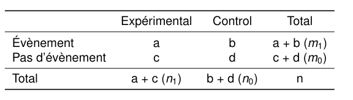

- \[RR = \frac{a/(a+c)}{b/(b+d)} \]
- \(\Delta\) \(RR\) is here the sample estimate of the relative risk, not the true population value

## CI of RR

- Log (natural logarithm) transform to compute the CI (Katz, 1978) \[ log(RR) \sim \mathcal{N} (log(\phi), \sigma_{logRR}^{2})\] with \(\phi\) the value of the relative risk in the population et \[\sigma_{logRR}^{2} = \frac{c}{a \times (a + c)} + \frac{d}{b \times (b + d)} \]
- CI of log(RR) : \[ log(RR) \pm Z_{\alpha/2} \times \sigma_{logRR} \]
- CI of RR : \[ e^{(log(RR) \pm Z_{\alpha/2} \times \sigma_{logRR})}\]

## CI of RR with R base

```
##
##       Acupuncture Control
##   yes          22      37
##   no          139     103
```

## CI of RR with R base

```r
a <- 22
b <- 37
c <- 139
d <- 103
RR <- (a/(a+c)) / (b / (b+d))
se <- sqrt((c / (a * (a + c))) + (d / (b * (b + d))))
round(exp(log(RR)
          + qnorm(c(0.5, 0.025, 0.975)) * se), 3)
```

```
## [1] 0.517 0.321 0.833
```

## RR with Epi

```r
effx(anypro5, type = "binary", eff = "RR",
     exposure = group, data = compl)
```

```
## ---------------------------------------------------------------------------
## response      :  anypro5
## type          :  binary
## exposure      :  group
##
## group is numeric
## effects are measured as relative risk
## ---------------------------------------------------------------------------
##
## effect of an increase of 1 unit in group on anypro5
## number of observations  301
##
## Effect   2.5%  97.5%
##  0.517  0.321  0.833
##
## Test for no effects of exposure on 1 df: p-value= 0.00533
```

## CI of OR

- Log transform to compute the CI (Woolf, 1955)

\[ log(OR) \sim \mathcal{N} (log(\theta), \sigma_{logOR}^{2})\]

with \(\theta\) the population value of the odds ratio

\[\sigma_{logOR}^{2} = \frac{1}{a} + \frac{1}{b} + \frac{1}{c} + \frac{1}{d} \]

CI of log(OR) : \[ log(OR) \pm Z_{\alpha/2} \times \sigma_{logOR} \]

CI of OR : \[ e^{(log(OR) \pm Z_{\alpha/2} \times \sigma_{logOR})}\]

## CI of OR with R base

```r
table(compl$anypro5_factor2, compl$arm)
```

```
##
##       Acupuncture Control
##   yes          22      37
##   no          139     103
```

## CI of OR with R base

```r
a <- 22
b <- 37
c <- 139
d <- 103
OR <- (a / c) / (b/d)
se <- sqrt(1/a + 1/b + 1/c + 1/d)
round(exp(log(OR) + qnorm(c(0.5, 0.025, 0.975)) * se), 3)
```

```
## [1] 0.441 0.245 0.792
```

## CI of OR with Epi

```r
effx(anypro5, type = "binary", eff = "OR",
     exposure = group, data = compl)
```

```
## ---------------------------------------------------------------------------
## response      :  anypro5
## type          :  binary
## exposure      :  group
##
## group is numeric
## effects are measured as odds ratios
## ---------------------------------------------------------------------------
##
## effect of an increase of 1 unit in group on anypro5
## number of observations  301
##
## Effect   2.5%  97.5%
##  0.441  0.245  0.792
##
## Test for no effects of exposure on 1 df: p-value= 0.00533
```

## Relation between OR and RR

- OR mathematically more interesting (better properties)
- RR more interpreatble
- Convert OR in RR, depends on \(p_0\)

\[RR = \displaystyle\frac{OR} {1 - p_0 + (p_0 \times OR)}\] - Grant. BMJ 2014;348:f7450 - If \(p_0\) is small, thedenominator \(\rightarrow\) 1, and \(RR \approx OR\)

## Relation between OR and RR (plot)

\[ RR = \frac{OR}{ (1 - p_0 + p_0 \times OR)} \] with \(p_0\) the baseline risk

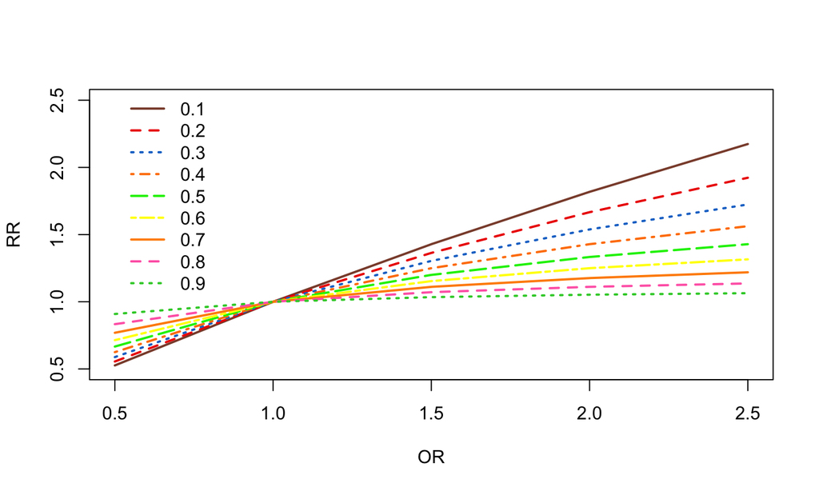